# Fachschaftsitzung Nr. 1

2025-11-04

## Tagesordnung

1. Reflexion letztes Protokoll
2. Information der Schulleitung an die Fachschaften von der Fachsprecher-DB
3. Vorschlag an die Schulleitung zum Fachschaftsvorsitz
4. Aufgabenverteilung in der Fachschaft
5. Reflexion Fachschaft-Beschlüsse u. ggf. neue Beschlüsse
6. Info und Diskussion zu SFZ-GFS
7. Neuanschaffungen in der Sammlung
8. Anwendungsbeispiel KI bei der Unterrichtsvorbereitung
9. Sonstiges

## 1. Reflexion letztes Protokoll

-> siehe heute Punkt 5

## 2. Information der Schulleitung an die Fachschaften

- Erinnerung an empfehlende und verbindliche Fachschaftsbeschlüsse:
  - nur die Beschlüsse zur Notengebung
- Anpassung Curricula:
  - erst wenn neue Bildungspläne vorliegen
- Forder- und Förderangebote in FS diskutieren
- Austausch über Pädagogik und Inhalte des Fachs: mind. einmal im Jahr ausführlich
- Fachschaftsvorsitz: Vorschlag an Schulleitung

## 3. Vorschlag an die Schulleitung zum Fachschaftsvorsitz

## Tagesordnung

1. Reflexion letztes Protokoll
2. Information der Schulleitung an die Fachschaften von der Fachsprecher-DB
3. Vorschlag an die Schulleitung zum Fachschaftsvorsitz
4. Aufgabenverteilung in der Fachschaft
5. Reflexion Fachschaft-Beschlüsse u. ggf. neue Beschlüsse
6. Info und Diskussion zu SFZ-GFS
7. Neuanschaffungen in der Sammlung
8. Anwendungsbeispiel KI bei der Unterrichtsvorbereitung
9. Sonstiges

## 4. Aufgabenverteilung in der Fachschaft

| Aufgabe | Zuständigkeit |
| --- | --- |
| Neubestellungen | Bü |
| Organisation Reparaturen | Bü |
| Wechsel Batterien / Sicherungen | Bie (unterstützend: Mü, Nb) |
| Kleinreparaturen | He (unterstützend: Mü, Nb) |
| Vorratsverwaltung | Sch |
| Pflege Sicherheitsordner | Wr |

**Neue Zuständigkeiten**

Änderungswünsche?

Wer möchte Bie ersetzen?

## Tagesordnung

1. Reflexion letztes Protokoll
2. Information der Schulleitung an die Fachschaften von der Fachsprecher-DB
3. Vorschlag an die Schulleitung zum Fachschaftsvorsitz
4. Aufgabenverteilung in der Fachschaft
5. Reflexion Fachschaft-Beschlüsse u. ggf. neue Beschlüsse
6. Info und Diskussion zu SFZ-GFS
7. Neuanschaffungen in der Sammlung
8. Anwendungsbeispiel KI bei der Unterrichtsvorbereitung
9. Sonstiges

## 5. Reflexion Fachschaft-Beschlüsse u. ggf. neue Beschlüsse

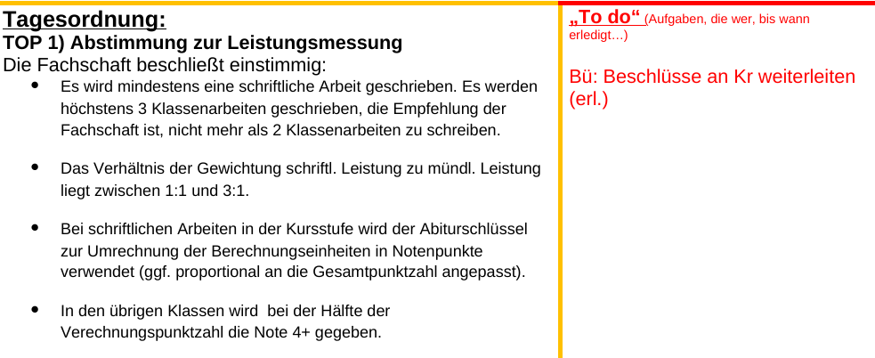

Gibt es Änderungswünsche?

## Tagesordnung

1. Reflexion letztes Protokoll
2. Information der Schulleitung an die Fachschaften von der Fachsprecher-DB
3. Vorschlag an die Schulleitung zum Fachschaftsvorsitz
4. Aufgabenverteilung in der Fachschaft
5. Reflexion Fachschaft-Beschlüsse u. ggf. neue Beschlüsse
6. Info und Diskussion zu SFZ-GFS
7. Neuanschaffungen in der Sammlung
8. Anwendungsbeispiel KI bei der Unterrichtsvorbereitung
9. Sonstiges

## 6. Info und Diskussion zu SFZ-GFS

Zwei Möglichkeiten:

1. SFZ-GFS als Physik-GFS
   - Bewertungsgrundlage muss überwiegend direkt überprüfbare Leistung sein
   - z.B. Vortrag + Kolloquium, reines Kolloqium
   - Verantwortung liegt beim Physiklehrer
   - muss sich zutrauen, das Thema bewerten zu können
2. SFZ-GFS wird von einer SFZ-Lehrkraft, die am Störck unterrichtet, bewertet:
   - wird von SL geklärt, ob das möglich ist
   - ist dann *keine* Physik-GFS
   - Physik-Fachlehrer ist nicht involviert

## Tagesordnung

1. Reflexion letztes Protokoll
2. Information der Schulleitung an die Fachschaften von der Fachsprecher-DB
3. Vorschlag an die Schulleitung zum Fachschaftsvorsitz
4. Aufgabenverteilung in der Fachschaft
5. Reflexion Fachschaft-Beschlüsse u. ggf. neue Beschlüsse
6. Info und Diskussion zu SFZ-GFS
7. Neuanschaffungen in der Sammlung
8. Anwendungsbeispiel KI bei der Unterrichtsvorbereitung
9. Sonstiges

## 7. Neuanschaffungen in der Sammlung

- Pasco-Fahrbahn mit Smartcarts + Zubehör
- noch nicht ausgepackt: Info erfolgt, wenn einsatzbereit

## Tagesordnung

1. Reflexion letztes Protokoll
2. Information der Schulleitung an die Fachschaften von der Fachsprecher-DB
3. Vorschlag an die Schulleitung zum Fachschaftsvorsitz
4. Aufgabenverteilung in der Fachschaft
5. Reflexion Fachschaft-Beschlüsse u. ggf. neue Beschlüsse
6. Info und Diskussion zu SFZ-GFS
7. Neuanschaffungen in der Sammlung
8. Anwendungsbeispiel KI bei der Unterrichtsvorbereitung
9. Sonstiges

## 8. Anwendungsbeispiel KI bei der Unterrichtsvorbereitung

aus Zeitgründen vertagt auf eine der nächsten Sitzungen

## Tagesordnung

1. Reflexion letztes Protokoll
2. Information der Schulleitung an die Fachschaften von der Fachsprecher-DB
3. Vorschlag an die Schulleitung zum Fachschaftsvorsitz
4. Aufgabenverteilung in der Fachschaft
5. Reflexion Fachschaft-Beschlüsse u. ggf. neue Beschlüsse
6. Info und Diskussion zu SFZ-GFS
7. Neuanschaffungen in der Sammlung
8. Anwendungsbeispiel KI bei der Unterrichtsvorbereitung
9. Sonstiges